# 1.sigmoid函数

## 1.1 从指数函数到sigmoid

首先我们来画出指数函数的基本图形： $$ y=e^x 和 y=e^{-x} $$

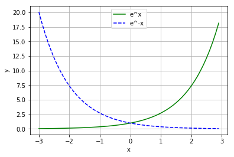

```python
import numpy as np
import matplotlib.pyplot as plt
X = np.arange(-3, 3, 0.1)
fig, ax = plt.subplots()
l1, = ax.plot(X, np.exp(X), 'k', color='g')
l2, = ax.plot(X, np.exp(-X), 'k--',color='b')
ax.legend((l1, l2), ('e^x', 'e^-x'), loc='upper center')
ax.set_xlabel('x')
ax.set_ylabel('y')
ax.grid(True)
plt.show()
```

从上图，我们得到了这样的几个信息，指数函数过(0,1)点，单调递增/递减，定义域为(−∞,+∞)，值域为(0,+∞)，再来我们看一下sigmoid函数的图像：

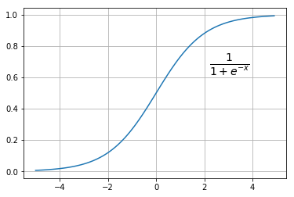

```python
X = np.arange(-5, 5, 0.1)
Y = 1/(1+np.exp(-X))
plt.plot(X, Y)
plt.grid(True)
tex = r'$\frac{1}{1+e^{-x}}$'
plt.text(2.2, 0.6, tex, fontsize=20, va='bottom')
plt.show()
```

如果直接把e−x放到分母上，就与ex图像一样了，所以分母加上1，就得到了上面的图像，定义域是(−∞,+∞)，值域是(0,1)，那么就有一个很好地特性了，就是不管x是什么，都可以得到(0,1)之间的值；

## 1.2 对数函数与sigmoid

首先来看一下对数函数的图像：

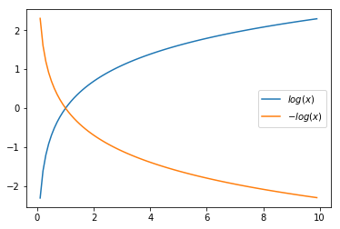

```python
import matplotlib.pyplot as plt
X = np.arange(0.1, 10., 0.1)
l1 = plt.plot(X, np.log(X))
l2 = plt.plot(X, -np.log(X))
plt.legend(('$log(x)$', '$-log(x)$'), loc='right')
plt.show()
```

 对数函数的图像如上，单调递减，有一个比较好的特性就是在(0,1)之间，在接近0的时候，就近无穷大，接近1的时候为0，如果我们把前面的sigmoid函数放到自变量的位置上，就得到了(0,1)的图像；

 我们如何来衡量一个结果与实际计算值得差距呢？一种思路就是，如果结果越接近，差值就越小，反之越大，这个函数就提供了这样一种思路，如果计算得到的值越接近1，那么那么表示与世界结果越接近，反之越远，所以利用这个函数，可以作为逻辑回归分类器的损失函数，如果所有的结果都能接近结果值，那么就越接近于0，如果所有的样本计算完成以后，结果接近于0，就表示计算结果与实际结果非常相近。

**（Logistic是Sigmoid的一种代表，Logistic又叫“对数几率函数”，与对数函数$ln(x)$不同）**

# 2、sigmoid函数求导

 sigmoid导数具体的推导过程如下： \begin{align} f'(x)&=(\frac{1}{1+e^{-x}})'\ &=\frac{e^{-x}}{(1+e^{-x})^2}\ &=\frac{1}{(1+e^{-x})}(1-\frac{1}{(1+e^{-x})})\ &=f(x)(1-f(x))\ \end{align}